# Statistical Computing with R (Due to Nov.29th)

#### 4. 와인 속에 아황산가스가 들어있다??

다소 약간 충격(?)적으로 들린다. 사실 지금 글을 쓰고 있는 내 자신도 생일이나 기타 여러 행사장에 가서 와인을 자주 마셔본 사람인데 와인 속에 아황산가스가 포함되어있다는 사실은 처음 본다. 와인이라는 것이 단순하게 알코올이 포함된 술의 종류 중 하나라고만 알고 있었는데 redwine과 whitewine에 대한 데이터를 보고 분석을 해보면서 참 흥미로운 것들을 많이 알게 되었다. 그럼 이제 와인 속의 아황산가스에 대해 몇가지 그림을 그려보도록 하자.

(1) scatter plot

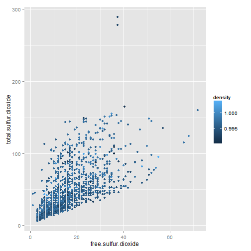

```r
ggplot(redwine, aes(free.sulfur.dioxide, total.sulfur.dioxide)) + geom_point(width = 1,
    aes(colour = density))
```

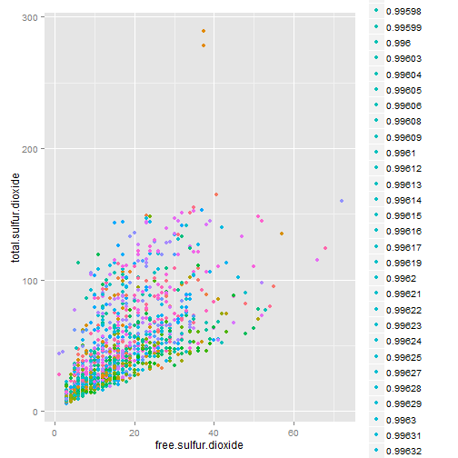

```r
ggplot(redwine, aes(free.sulfur.dioxide, total.sulfur.dioxide)) + geom_point(width = 1,
    aes(colour = factor(density)))
```

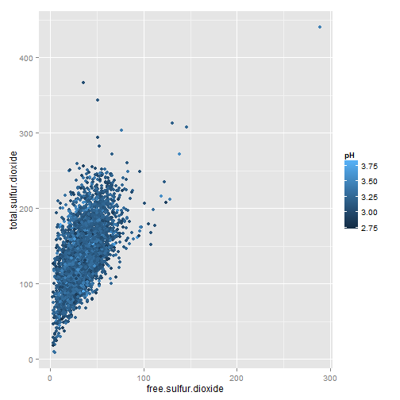

```r
ggplot(whitewine, aes(free.sulfur.dioxide, total.sulfur.dioxide)) + geom_point(width = 1,
    aes(colour = pH))
```

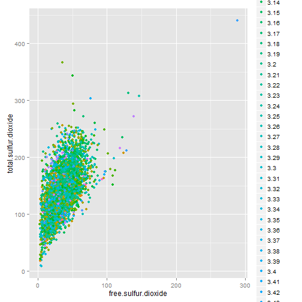

```r
ggplot(whitewine, aes(free.sulfur.dioxide, total.sulfur.dioxide)) + geom_point(width = 1,
    aes(colour = factor(pH)))
```

아황산가스의 양과 총 아황산가스의 양의 상관관계를 알아보기 위해 산점도를 그리고 밀도와 산성도에 따라 색깔을 구분해 봤다. 대체적으로 양의 상관관계를 나타내는 것으로 보여지지만 강하다고는 할 수 없을 듯 하다.

(2) histogram

```
## stat_bin: binwidth defaulted to range/30. Use 'binwidth = x' to adjust
## this.
```

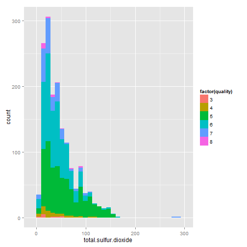

```r
ggplot(redwine, aes(total.sulfur.dioxide, fill = factor(quality))) + geom_histogram()
```

```
## stat_bin: binwidth defaulted to range/30. Use 'binwidth = x' to adjust
## this.
```

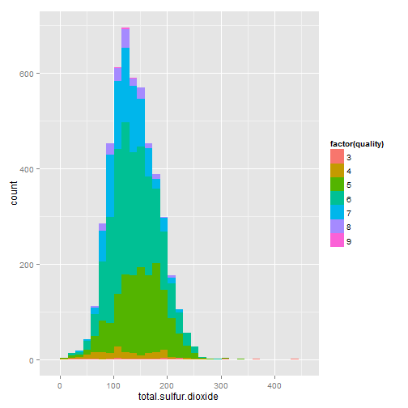

```r
ggplot(whitewine, aes(total.sulfur.dioxide, fill = factor(quality))) + geom_histogram()
```

총 아황산가스의 양에 대한 히스토그램을 그리고 와인의 상태에 따라 색을 다르게 입혀봤다.

(3) violin chart

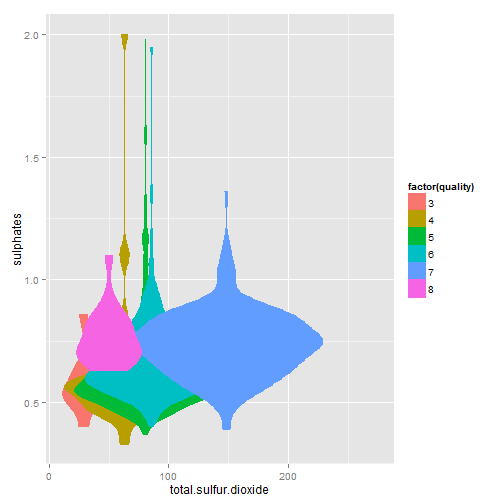

```r
ggplot(redwine, aes(total.sulfur.dioxide, sulphates, fill = factor(quality))) +
    geom_violin(aes(colour = factor(quality)))
```

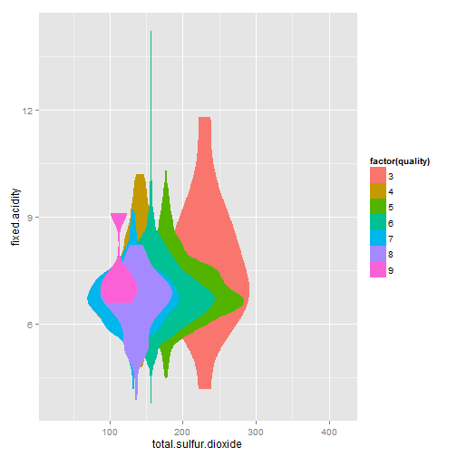

```r
ggplot(whitewine, aes(total.sulfur.dioxide, fixed.acidity, fill = factor(quality))) +
    geom_violin(aes(colour = factor(quality)))
```

총 아황산가스의 양에 따른 황산염의 양과 고유산성도의 분포를 알아보기 위해 violin chart를 그려봤다. 이름 그대로 정말 바이올린의 모양을 하고 있다. 대체적으로 황산염의 농도는 0.7 근방에 밀집해 있고, 고유산성도는 7 근방에 밀집해 있음을 확인이 가능하다.

이제부터 와인 마실 일이 생기면 신중(?)하게 생각하고 마셔야 할 듯 하다.

#### 5. 아황산가스와 황산염과의 관계에 관한 분석

와인 속에 들어있는 물질 중 신기한 것을 하나 더 얘기하자면 황산염이라고 할 수 있을 듯. 와인을 단순히 마시고 즐기는 술이라고만 생각했는데 계속 깊숙하게 분석해보니까 신기한 것들을 많이 숨기고 있고 알면 알수록 더 재미있는 녀석인 듯 하다. 여기서는 아황산가스와 황산염의 농도가 과연 관계가 있다고 할 수 있는지 알아보고자 한다. 그럼 이제 두 와인에 따라 각각 그림을 그려보도록 하자. 그럼 먼저 빨간색 와인부터 시작해보자.

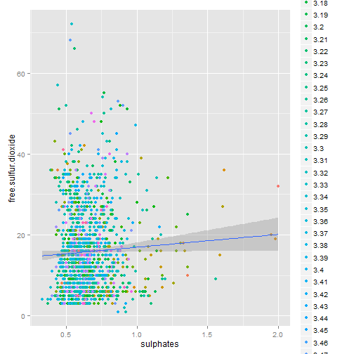

```r
ggplot(redwine, aes(sulphates, free.sulfur.dioxide)) + geom_point(aes(colour = factor(pH))) +
    geom_smooth(method = lm)
```

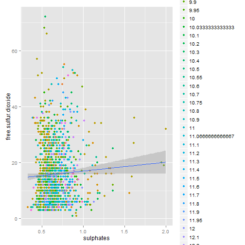

```r
ggplot(redwine, aes(sulphates, free.sulfur.dioxide)) + geom_point(aes(colour = factor(alcohol))) +
    geom_smooth(method = lm)
```

이제 흰색 와인에 대해서도 그려보자.

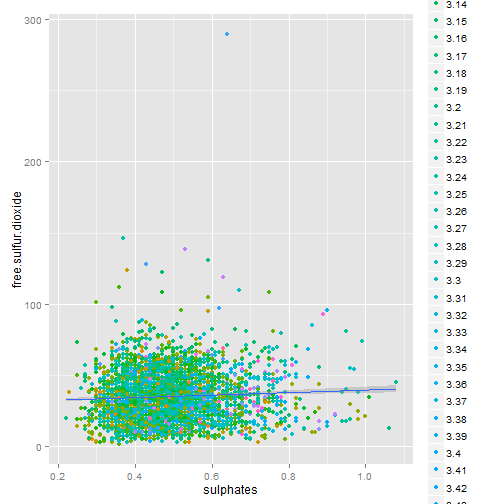

```r
ggplot(whitewine, aes(sulphates, free.sulfur.dioxide)) + geom_point(aes(colour = factor(pH))) +
    geom_smooth(method = lm)
```

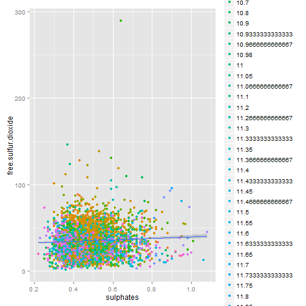

```r
ggplot(whitewine, aes(sulphates, free.sulfur.dioxide)) + geom_point(aes(colour = factor(alcohol))) +
    geom_smooth(method = lm)
```

두 경우 모두 뚜렷한 상관관계가 있다고 볼 수는 없을 듯 하다. 그림에 추가해서 회귀직선을 그려봤는데 그 직선이 데이터를 충분히 설명하고 있다고 얘기하기도 곤란하다.

#### 6. 와인 속에 들어있는 설탕에 관한 고찰

와인이라는게 술의 일종이기 때문에 쓴맛이 있는건 사실이지만 특유의 달콤한 향기도 가지고 있기 때문에 매력이 있다고 생각한다. 이러한 향기와 풍미를 내기 위해서 기본적으로 필요한 설탕을 빼놓을 수 없을 것 같다. 설탕을 상황에 따라 어느정도 그리고 어떻게 조절해서 넣느냐에 따라 와인의 맛과 질이 달라질 수 있기 때문이다. 그럼 먼저 와인에 들어있는 설탕의 양과 와인의 질이 어떻게 관련이 있는지 그래프를 통해서 확인해보도록 하자.

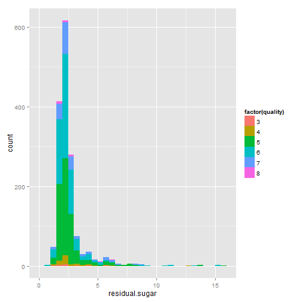

```r
ggplot(redwine, aes(residual.sugar, fill = factor(quality))) + geom_bar(binwidth = 0.5)
```

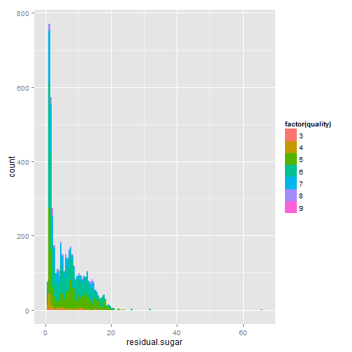

```r
ggplot(whitewine, aes(residual.sugar, fill = factor(quality))) + geom_bar(binwidth = 0.5)
```

두 그래프를 비교해보니 흰색 와인이 빨간색 와인보다 첨가된 설탕의 양이 상대적으로 더 많다는 것을 확인할 수 있다. 그러면 이제 설탕의 양과 밀도, 그리고 산성도는 어떤 관계가 있는지 살펴보자.

먼저 빨간색 와인의 경우이다.

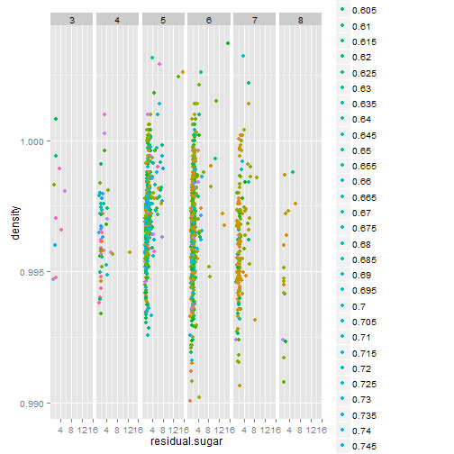

```r
ggplot(redwine, aes(residual.sugar, density)) + geom_point(aes(colour = factor(volatile.acidity))) +
    facet_grid(. ~ quality)
```

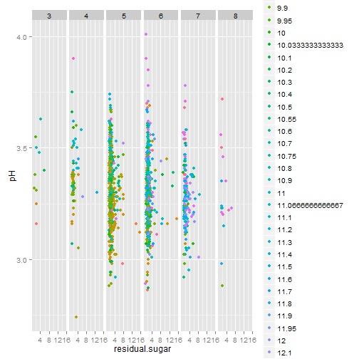

```r
ggplot(redwine, aes(residual.sugar, pH)) + geom_point(aes(colour = factor(alcohol))) +
    facet_grid(. ~ quality)
```

그 다음으로 흰색 와인의 경우이다.

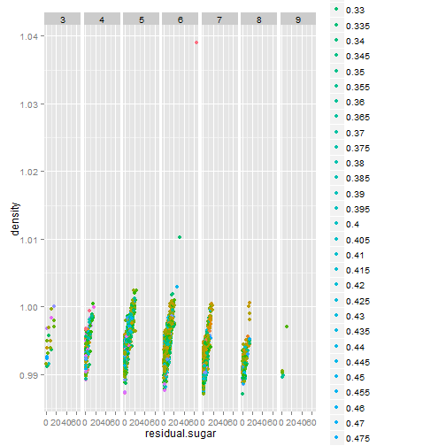

```r
ggplot(whitewine, aes(residual.sugar, density)) + geom_point(aes(colour = factor(volatile.acidity))) +
    facet_grid(. ~ quality)
```

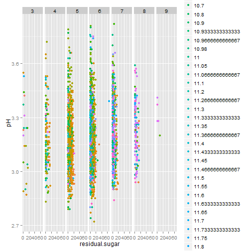

```r
ggplot(whitewine, aes(residual.sugar, pH)) + geom_point(aes(colour = factor(alcohol))) +
    facet_grid(. ~ quality)
```

그림을 비교해서 살펴보도록 하자. 밀도의 경우 빨간색 와인에서는 그 분포가 0.996 근방에서 밀집되어 있는 것으로 보인다. 흰색 와인의 경우도 그러한 경향이 있지만 질의 수준이 6인 경우에 상대적으로 밀도가 특이하게 높은 점이 있는 것이 특징이다. 산성도의 경우에는 빨간색 와인, 흰색 와인 모두 3.3 근방에 밀집되어 있지만 흰색 와인이 상대적으로 산성도가 약간 더 강한 것으로 보여진다.

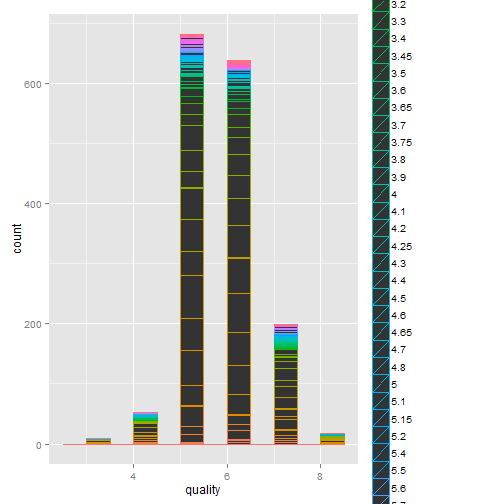

```r
ggplot(redwine, aes(quality)) + geom_bar(binwidth = 0.5, aes(colour = factor(residual.sugar)))
```

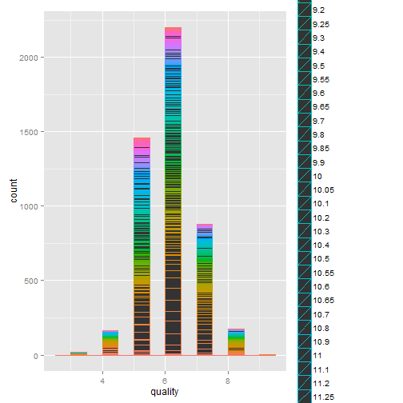

```r
ggplot(whitewine, aes(quality)) + geom_bar(binwidth = 0.5, aes(colour = factor(residual.sugar)))
```

위의 두 그림은 와인의 상태에 따른 막대그래프에 설탕의 양에 따라 색깔을 다르게 하여 그려본 그래프이다.

#### 7. 와인의 색깔에 따른 고유한 산성도

와인은 색깔에 따라 제조하는 방법이 차이가 있을 수 있기 때문에 고유산성도가 달라질 수 있다. 여기서 고유산성도는 우리가 일반적으로 알고 있는 pH로 표기되는 산성도하고는 다른 것임을 인지할 필요가 있다. 일반적인 술도 만드는 방법, 걸리는 시간 등에 따라 고유의 특성이 나타날 수 있다. 이러한 요소들 중 하나가 바로 고유산성도라고 생각하면 이해가 쉬울 것이다. 이제 여러가지 그래프들을 통해서 살펴보도록 하자.

(1) red wine

```
## stat_bin: binwidth defaulted to range/30. Use 'binwidth = x' to adjust
## this.
```

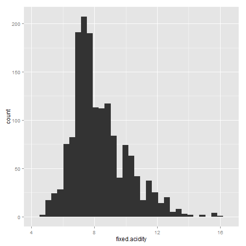

```r
ggplot(redwine, aes(fixed.acidity)) + geom_histogram()
```

```
## stat_bin: binwidth defaulted to range/30. Use 'binwidth = x' to adjust
## this.
```

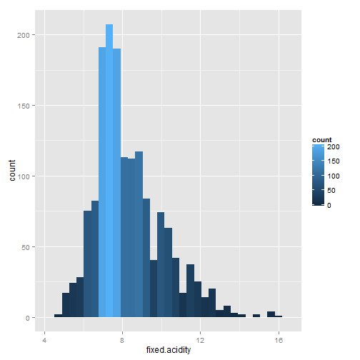

```r
ggplot(redwine, aes(fixed.acidity)) + geom_histogram(aes(fill = ..count..))
```

```
## stat_bin: binwidth defaulted to range/30. Use 'binwidth = x' to adjust
## this.
```

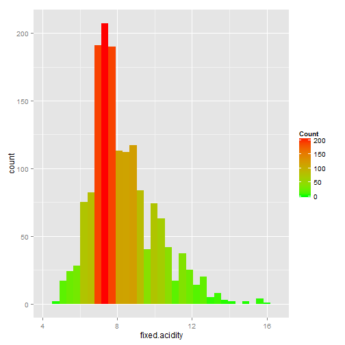

```r
ggplot(redwine, aes(fixed.acidity)) + geom_histogram(aes(fill = ..count..)) +
    scale_fill_gradient("Count", low = "green", high = "red")
```

```
## stat_bin: binwidth defaulted to range/30. Use 'binwidth = x' to adjust
## this.
```

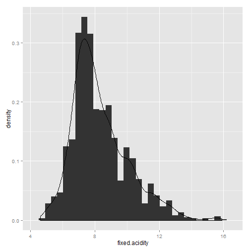

```r
ggplot(redwine, aes(fixed.acidity)) + geom_histogram(aes(y = ..density..)) +
    geom_density()
```

```
## stat_bin: binwidth defaulted to range/30. Use 'binwidth = x' to adjust
## this.
```

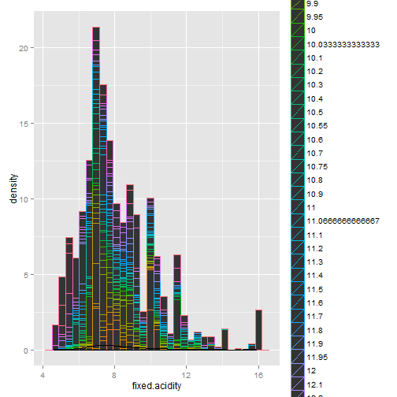

```r
ggplot(redwine, aes(fixed.acidity)) + geom_histogram(aes(y = ..density.., colour = factor(alcohol))) +
    geom_density()
```

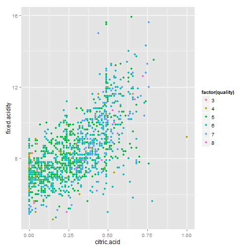

```r
ggplot(redwine, aes(citric.acid, fixed.acidity)) + geom_point(aes(colour = factor(quality)))
```

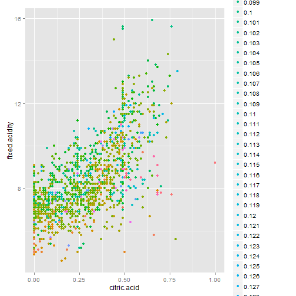

```r
ggplot(redwine, aes(citric.acid, fixed.acidity)) + geom_point(aes(colour = factor(chlorides)))
```

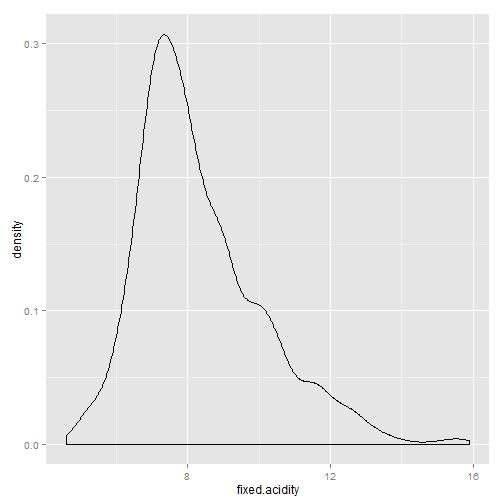

```r
ggplot(redwine, aes(fixed.acidity)) + geom_density()
```

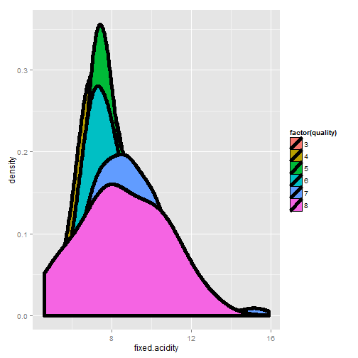

```r
ggplot(redwine, aes(fixed.acidity)) + geom_density(aes(fill = factor(quality)),
    size = 2)
```

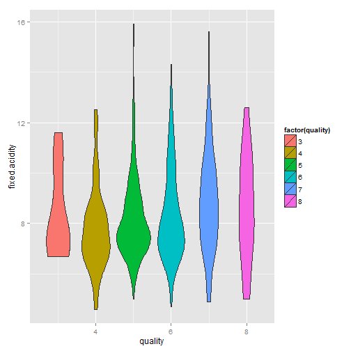

```r
ggplot(redwine, aes(quality, fixed.acidity)) + geom_violin(aes(fill = factor(quality)))
```

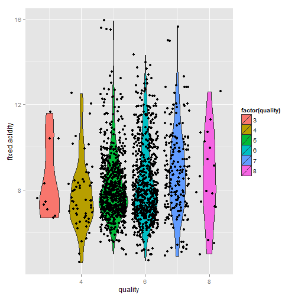

```r
ggplot(redwine, aes(quality, fixed.acidity)) + geom_violin(aes(fill = factor(quality))) +
    geom_jitter()
```

(2) white wine

```
## stat_bin: binwidth defaulted to range/30. Use 'binwidth = x' to adjust
## this.
```

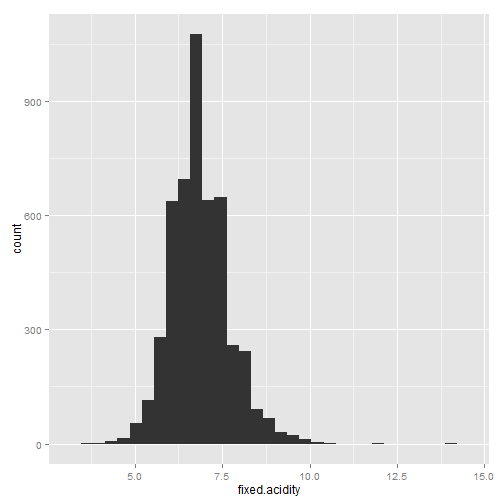

```r
ggplot(whitewine, aes(fixed.acidity)) + geom_histogram()
```

```
## stat_bin: binwidth defaulted to range/30. Use 'binwidth = x' to adjust
## this.
```

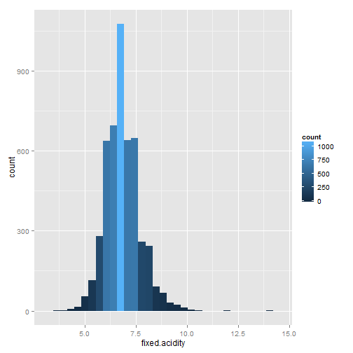

```r
ggplot(whitewine, aes(fixed.acidity)) + geom_histogram(aes(fill = ..count..))
```

```
## stat_bin: binwidth defaulted to range/30. Use 'binwidth = x' to adjust
## this.
```

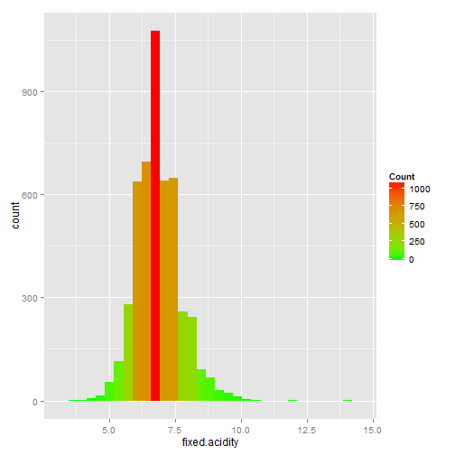

```r
ggplot(whitewine, aes(fixed.acidity)) + geom_histogram(aes(fill = ..count..)) +
    scale_fill_gradient("Count", low = "green", high = "red")
```

```
## stat_bin: binwidth defaulted to range/30. Use 'binwidth = x' to adjust
## this.
```

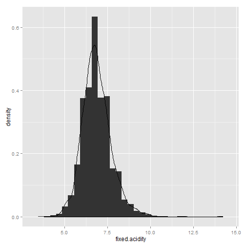

```r
ggplot(whitewine, aes(fixed.acidity)) + geom_histogram(aes(y = ..density..)) +
    geom_density()
```

```
## stat_bin: binwidth defaulted to range/30. Use 'binwidth = x' to adjust
## this.
```

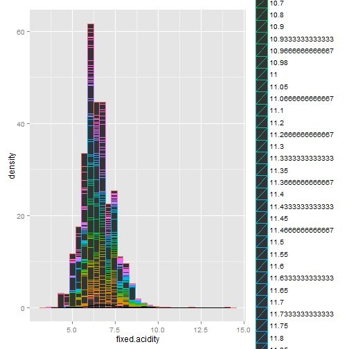

```r
ggplot(whitewine, aes(fixed.acidity)) + geom_histogram(aes(y = ..density..,
    colour = factor(alcohol))) + geom_density()
```

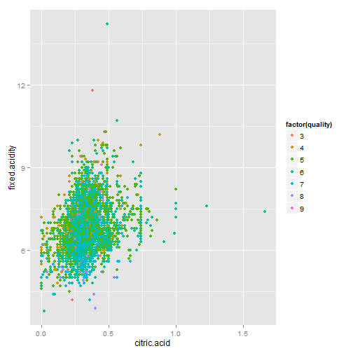

```r
ggplot(whitewine, aes(citric.acid, fixed.acidity)) + geom_point(aes(colour = factor(quality)))
```

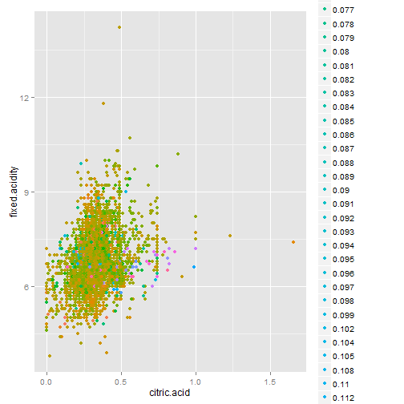

```r
ggplot(whitewine, aes(citric.acid, fixed.acidity)) + geom_point(aes(colour = factor(chlorides)))
```

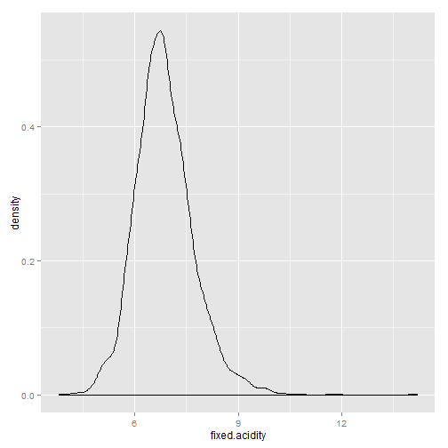

```r
ggplot(whitewine, aes(fixed.acidity)) + geom_density()
```

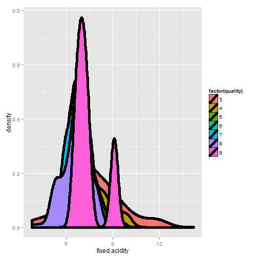

```r
ggplot(whitewine, aes(fixed.acidity)) + geom_density(aes(fill = factor(quality)),
    size = 2)
```

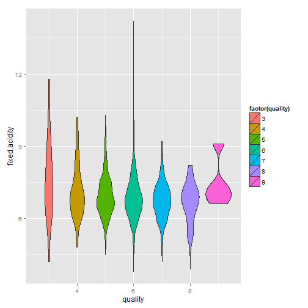

```r
ggplot(whitewine, aes(quality, fixed.acidity)) + geom_violin(aes(fill = factor(quality)))
```

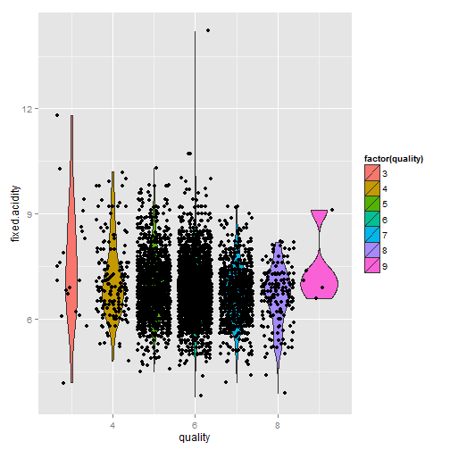

```r
ggplot(whitewine, aes(quality, fixed.acidity)) + geom_violin(aes(fill = factor(quality))) +
    geom_jitter()
```

빨간색 와인과 흰색 와인 모두 대체적으로 상태의 수준이 중간인 정도에서 분포가 더 크게 나타남을 확인할 수 있다. 또한 히스토그램과 밀도곡선을 통해 대략적인 분포를 알아봤고, 시각적으로 볼 수 있도록 요소에 따라 색깔을 다르게 칠해봤다. 추가적으로 구연산과 고유산성도 사이의 관계가 존재하는지 알아보기 위해 산점도도 그려봤는데 강하지는 않지만 양의 상관관계를 가지고 있다고 판단된다.

#### 8. 데이터의 요소들에 대한 산점도

이제 와인에 대한 수많은 정보들을 알려주고 있는 요소들에 대한 산점도를 그려봄으로서 한번에 파악하기 어려운 데이터에 대한 concept을 잡아보도록 하자. 산점도 행렬을 그림으로서 12가지 요소들에 대한 상관관계를 한눈에 파악할 수 있을 것이다.

(1) red wine

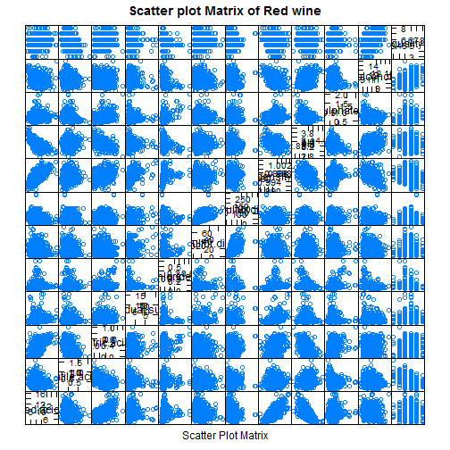

```r
splom(redwine[1:12], main = "Scatter plot Matrix of Red wine")
```

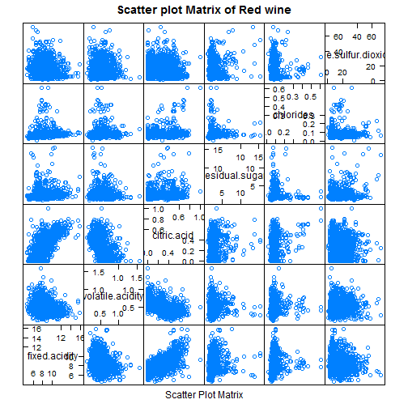

```r
splom(redwine[1:6], main = "Scatter plot Matrix of Red wine")
```

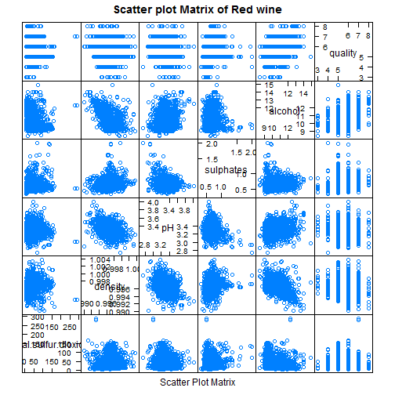

```r
splom(redwine[7:12], main = "Scatter plot Matrix of Red wine")
```

(2) white wine

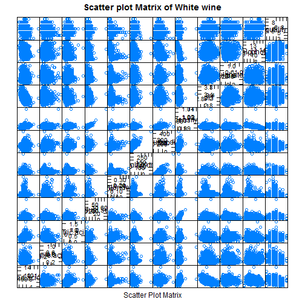

```r
splom(whitewine[1:12], main = "Scatter plot Matrix of White wine")
```

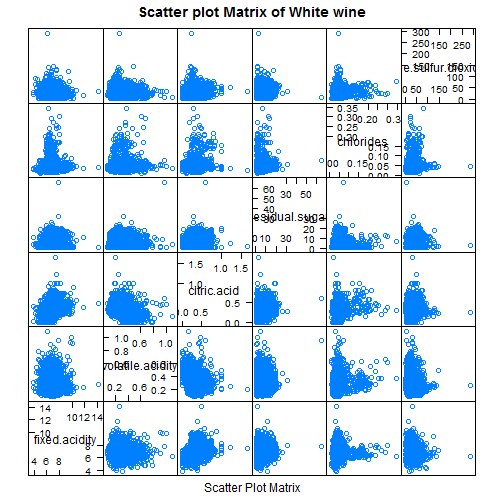

```r
splom(whitewine[1:6], main = "Scatter plot Matrix of White wine")
```

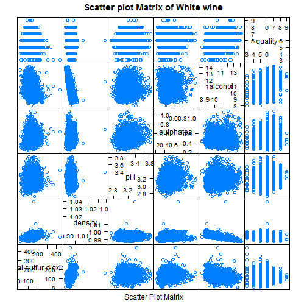

```r
splom(whitewine[7:12], main = "Scatter plot Matrix of White wine")
```

#### 9. Summary of Red wine and White wine

마지막으로 redwine과 whitewine 이 두 데이터에 대한 요약정리를 해보도록 하겠다.

(1) Red wine

```r
summary(redwine)
```

```
##  fixed.acidity   volatile.acidity  citric.acid    residual.sugar
##  Min.   : 4.60   Min.   :0.120    Min.   :0.000   Min.   : 0.90
##  1st Qu.: 7.10   1st Qu.:0.390    1st Qu.:0.090   1st Qu.: 1.90
##  Median : 7.90   Median :0.520    Median :0.260   Median : 2.20
##  Mean   : 8.32   Mean   :0.528    Mean   :0.271   Mean   : 2.54
##  3rd Qu.: 9.20   3rd Qu.:0.640    3rd Qu.:0.420   3rd Qu.: 2.60
##  Max.   :15.90   Max.   :1.580    Max.   :1.000   Max.   :15.50
##    chlorides      free.sulfur.dioxide total.sulfur.dioxide    density
##  Min.   :0.0120   Min.   : 1.0        Min.   :  6.0        Min.   :0.990
##  1st Qu.:0.0700   1st Qu.: 7.0        1st Qu.: 22.0        1st Qu.:0.996
##  Median :0.0790   Median :14.0        Median : 38.0        Median :0.997
##  Mean   :0.0875   Mean   :15.9        Mean   : 46.5        Mean   :0.997
##  3rd Qu.:0.0900   3rd Qu.:21.0        3rd Qu.: 62.0        3rd Qu.:0.998
##  Max.   :0.6110   Max.   :72.0        Max.   :289.0        Max.   :1.004
##        pH         sulphates        alcohol        quality
##  Min.   :2.74   Min.   :0.330   Min.   : 8.4   Min.   :3.00
##  1st Qu.:3.21   1st Qu.:0.550   1st Qu.: 9.5   1st Qu.:5.00
##  Median :3.31   Median :0.620   Median :10.2   Median :6.00
##  Mean   :3.31   Mean   :0.658   Mean   :10.4   Mean   :5.64
##  3rd Qu.:3.40   3rd Qu.:0.730   3rd Qu.:11.1   3rd Qu.:6.00
##  Max.   :4.01   Max.   :2.000   Max.   :14.9   Max.   :8.00
```

(2) White wine

```r
summary(whitewine)
```

```
##  fixed.acidity   volatile.acidity  citric.acid    residual.sugar
##  Min.   : 3.80   Min.   :0.080    Min.   :0.000   Min.   : 0.60
##  1st Qu.: 6.30   1st Qu.:0.210    1st Qu.:0.270   1st Qu.: 1.70
##  Median : 6.80   Median :0.260    Median :0.320   Median : 5.20
##  Mean   : 6.86   Mean   :0.278    Mean   :0.334   Mean   : 6.39
##  3rd Qu.: 7.30   3rd Qu.:0.320    3rd Qu.:0.390   3rd Qu.: 9.90
##  Max.   :14.20   Max.   :1.100    Max.   :1.660   Max.   :65.80
##    chlorides      free.sulfur.dioxide total.sulfur.dioxide    density
##  Min.   :0.0090   Min.   :  2.0       Min.   :  9          Min.   :0.987
##  1st Qu.:0.0360   1st Qu.: 23.0       1st Qu.:108          1st Qu.:0.992
##  Median :0.0430   Median : 34.0       Median :134          Median :0.994
##  Mean   :0.0458   Mean   : 35.3       Mean   :138          Mean   :0.994
##  3rd Qu.:0.0500   3rd Qu.: 46.0       3rd Qu.:167          3rd Qu.:0.996
##  Max.   :0.3460   Max.   :289.0       Max.   :440          Max.   :1.039
##        pH         sulphates       alcohol        quality
##  Min.   :2.72   Min.   :0.22   Min.   : 8.0   Min.   :3.00
##  1st Qu.:3.09   1st Qu.:0.41   1st Qu.: 9.5   1st Qu.:5.00
##  Median :3.18   Median :0.47   Median :10.4   Median :6.00
##  Mean   :3.19   Mean   :0.49   Mean   :10.5   Mean   :5.88
##  3rd Qu.:3.28   3rd Qu.:0.55   3rd Qu.:11.4   3rd Qu.:6.00
##  Max.   :3.82   Max.   :1.08   Max.   :14.2   Max.   :9.00
```

결과물에는 와인의 특성을 결정짓는 12가지 요소들에 대한 최소값, 최대값, 중위수, 그리고 제 1,2,3 사분위수가 표시되어 있다.

#### 글을 쓰면서 느낀점(소감)

사실 R이라는 언어가 굉장히 강력하고 앞으로 데이터를 분석하는 데 있어서 큰 기여를 할 것이라고만 알고 통계계산 수업을 들어왔다. 하지만 이번 학기가 거의 끝나가는 이 시점에서 R에 대해 큰 매력을 느끼고 있다. 확률분포론 시간에 R을 이용해서 확률분포에 대한 p.m.f와 p.d.f를 그려보고 아울러 통계계산 시간에 R을 실제적으로 많이 다루어봄으로서 R을 잘 다루는 능력이 있으면 나중에 졸업하고 대학원에 가서 공부를 할 때 뿐만 아니라 통계관련 기업에 들어가서 데이터를 수집하고 분석을 할 때 정말 유용하게 쓸 수 있을 것 같다는 확신이 들었다. 지금도 R은 전세계에 수많은 통계학자들이 자신의 정보들을 공유해서 새로운 기능들을 만들어내고 이러한 것들을 바탕으로 계속 진화하고 있다. 앞으로도 R에 대해서 더 많은 관심을 가져볼 생각이다.